# Red & White Wine Analysis

# by Sergio Marfull

## 1. About datasets

### 1.1. Description

This datasets are public available for research. The details are described in [Cortez et al., 2009].

P. Cortez, A. Cerdeira, F. Almeida, T. Matos and J. Reis. *“Modeling wine preferences by data mining from physicochemical properties”*. In Decision Support Systems, Elsevier, 47(4):547-553. ISSN: 0167-9236.

Available at:

- [Elsevier](http://dx.doi.org/10.1016/j.dss.2009.05.016)
- [Pre-press (pdf)](http://www3.dsi.uminho.pt/pcortez/winequality09.pdf)
- bib

### 1.2. Sample size:

- **Red wine**: 1,599 samples;
- **White wine**: 4,898 samples.

### 1.3. Attributes:

These datasets consist of 11 attributes and one output variable (below)

- **Fixed acidity** (tartaric acid - $g / dm^3$): most acids involved with wine or fixed or nonvolatile (do not evaporate readily)
- **Volatile acidity** (acetic acid - $g / dm^3$): the amount of acetic acid in wine, which at too high of levels can lead to an unpleasant, vinegar taste
- **Citric acid** ($g / dm^3$): found in small quantities, citric acid can add ‘freshness’ and flavor to wines
- **Residual sugar** ($g / dm^3$): the amount of sugar remaining after fermentation stops, it’s rare to find wines with less than 1 $g/l$ and wines with greater than 45 $g/l$ are considered sweet
- **Chlorides** (sodium chloride - $g / dm^3$): the amount of salt in the wine
- **Free sulfur dioxide** ($mg / dm^3$): the free form of $SO_{2}$ exists in equilibrium between molecular $SO_{2}$ (as a dissolved gas) and bisulfite ion; it prevents microbial growth and the oxidation of wine
- **Total sulfur dioxide** ($mg / dm^3$): amount of free and bound forms of $SO_{2}$; in low concentrations, $SO_{2}$ is mostly undetectable in wine, but at free $SO_{2}$ concentrations over 50 ppm, $SO_{2}$ becomes evident in the nose and taste of wine
- **Density** ($g / cm^3$): the density of water is close to that of water depending on the percent alcohol and sugar content
- **pH**: describes how acidic or basic a wine is on a scale from 0 (very acidic) to 14 (very basic); most wines are between 3-4 on the pH scale
- **Sulphates** (potassium sulphate - $g / dm3$): a wine additive which can contribute to sulfur dioxide gas ($SO_{2}$) levels, wich acts as an antimicrobial and antioxidant
- **Alcohol** (% volume): the percent alcohol content of the wine
- **Quality** (score between 0 and 10): output variable, based on sensory data

### 1.4. Data Summary:

It will be interesting to combine white and red wine datasets as this could make richer the study. The process of merging them is quite direct as they present identical structure. In order to further analyses, we will add a categorical variable called ‘type’ with ‘red’ and ‘white’ values.

The main scope of this study will be to analyze the main variables that affect the quality of the wine, for both red and white, and if they are the same. In order to simplify that task, we will add another variable called ‘category’ that groups the existing ‘quality’ (1-10) into 3 new categories (excellent, average, deficient)

We will also have a look on some similarities and differences between the types of wine throughout the analysis.

```r
library(ggplot2)
library(dplyr)
library(gridExtra)
library(corrplot)
```

[output not shown]

```r
summary(wine_data)
```

```
       X        fixed.acidity    volatile.acidity  citric.acid     residual.sugar
 Min.   :   1   Min.   : 3.800   Min.   :0.0800   Min.   :0.0000   Min.   : 0.600
 1st Qu.: 813   1st Qu.: 6.400   1st Qu.:0.2300   1st Qu.:0.2500   1st Qu.: 1.800
 Median :1650   Median : 7.000   Median :0.2900   Median :0.3100   Median : 3.000
 Mean   :2044   Mean   : 7.215   Mean   :0.3397   Mean   :0.3186   Mean   : 5.443
 3rd Qu.:3274   3rd Qu.: 7.700   3rd Qu.:0.4000   3rd Qu.:0.3900   3rd Qu.: 8.100
 Max.   :4898   Max.   :15.900   Max.   :1.5800   Max.   :1.6600   Max.   :65.800
   chlorides       free.sulfur.dioxide total.sulfur.dioxide    density             pH
 Min.   :0.00900   Min.   :  1.00      Min.   :  6.0        Min.   :0.9871   Min.   :2.720
 1st Qu.:0.03800   1st Qu.: 17.00      1st Qu.: 77.0        1st Qu.:0.9923   1st Qu.:3.110
 Median :0.04700   Median : 29.00      Median :118.0        Median :0.9949   Median :3.210
 Mean   :0.05603   Mean   : 30.53      Mean   :115.7        Mean   :0.9947   Mean   :3.219
 3rd Qu.:0.06500   3rd Qu.: 41.00      3rd Qu.:156.0        3rd Qu.:0.9970   3rd Qu.:3.320
 Max.   :0.61100   Max.   :289.00      Max.   :440.0        Max.   :1.0390   Max.   :4.010
   sulphates         alcohol         quality          type             category
 Min.   :0.2200   Min.   : 8.00   Min.   :3.000   Length:6497        Length:6497
 1st Qu.:0.4300   1st Qu.: 9.50   1st Qu.:5.000   Class :character   Class :character
 Median :0.5100   Median :10.30   Median :6.000   Mode  :character   Mode  :character
 Mean   :0.5313   Mean   :10.49   Mean   :5.818
 3rd Qu.:0.6000   3rd Qu.:11.30   3rd Qu.:6.000
 Max.   :2.0000   Max.   :14.90   Max.   :9.000
```

We can appreciate that some variables have much variability (residual sugar, free and total sulfur dioxide, chlorides, acidity) due to outliers that can be caused by bad measures for examples. We can also see some 0-values in the variable citric acid, which could be some kind of measuring error or lack of info of these datasets.

# Univariate Plots Section

In this section, we will have a look on the distribution of the different variables for both red and white wines and comparing their distributions to get a deeper understanding of the key differences between both types of wine.

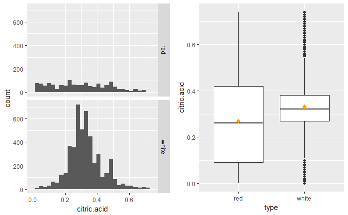

```r
p1_citric.acid <- ggplot(wine_data, aes(citric.acid)) +
  geom_histogram() +
  facet_grid(type~.)+
  scale_x_continuous(lim = c(min(wine_data$citric.acid), quantile(wine_data$citric.acid,  probs = c(99.5)/100)))

p2_citric.acid <- ggplot(wine_data, aes(type, citric.acid))+
  geom_boxplot()+
  stat_summary(fun.y=mean, color="orange", geom="point",
               shape=18, size=3)+
  scale_y_continuous(lim = c(min(wine_data$citric.acid), quantile(wine_data$citric.acid,  probs = c(99.5)/100)))
grid.arrange(p1_citric.acid, p2_citric.acid, nrow = 1)
```

We can see a wide variability of citric acid for the red wine with a quite homogeneous distribution, while white wine is normally distributed. In the boxplot, we can appreciate that variability for the red wine, but both types don’t have significantly different volumes of citric acid

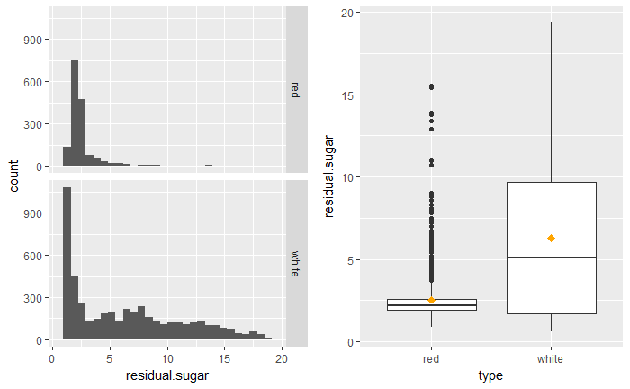

```r
p1_residual.sugar <- ggplot(wine_data, aes(residual.sugar)) +
  geom_histogram() +
  facet_grid(type~.)+
  scale_x_continuous(lim = c(min(wine_data$residual.sugar), quantile(wine_data$residual.sugar,  probs = c(99.5)/100)))

p2_residual.sugar <- ggplot(wine_data, aes(type, residual.sugar))+
  geom_boxplot()+
  stat_summary(fun.y=mean, color="orange", geom="point",
               shape=18, size=3)+
  scale_y_continuous(lim = c(min(wine_data$residual.sugar), quantile(wine_data$residual.sugar,  probs = c(99.5)/100)))
grid.arrange(p1_residual.sugar, p2_residual.sugar, nrow = 1)
```

In that case, we appreciate two right-skewed distribution and a clearly wider range of residual sugar volumes for the white wine (2-10) vs. red wine (~2). That makes sense because white wine tastes generally sweeter even though we can also see white wines with similar sugar volumes than white wine.

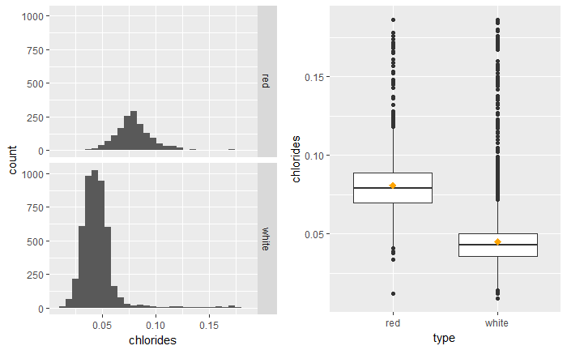

```r
p1_chlorides <- ggplot(wine_data, aes(chlorides)) +
  geom_histogram() +
  facet_grid(type~.)+
  scale_x_continuous(lim = c(min(wine_data$chlorides), quantile(wine_data$chlorides,  probs = c(99)/100)))

p2_chlorides <- ggplot(wine_data, aes(type, chlorides))+
  geom_boxplot()+
  stat_summary(fun.y=mean, color="orange", geom="point",
               shape=18, size=3)+
  scale_y_continuous(lim = c(min(wine_data$chlorides), quantile(wine_data$chlorides,  probs = c(99)/100)))
grid.arrange(p1_chlorides, p2_chlorides, nrow = 1)
```

Chlorides are normally distributed for red wine and right-skewed for white wine, with a very long tail. We appreciate that white wine has significantly less volume of chlorides than red wine.

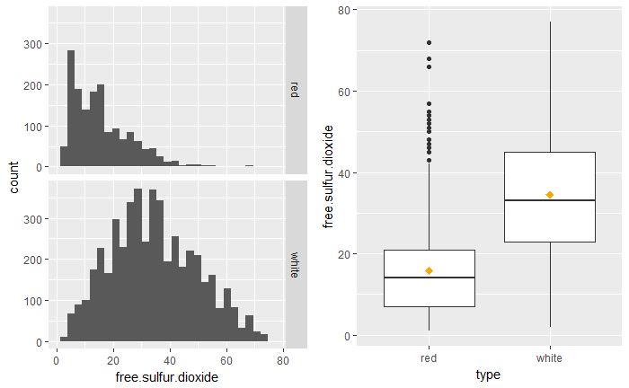

```r
p1_free.sulfur.dioxide <- ggplot(wine_data, aes(free.sulfur.dioxide)) +
  geom_histogram() +
  facet_grid(type~.)+
  scale_x_continuous(lim = c(min(wine_data$free.sulfur.dioxide), quantile(wine_data$free.sulfur.dioxide,  probs = c(99)/100)))
p2_free.sulfur.dioxide <- ggplot(wine_data, aes(type, free.sulfur.dioxide))+
  geom_boxplot()+
  stat_summary(fun.y=mean, color="orange", geom="point",
               shape=18, size=3)+
  scale_y_continuous(lim = c(min(wine_data$free.sulfur.dioxide), quantile(wine_data$free.sulfur.dioxide,  probs = c(99)/100)))
grid.arrange(p1_free.sulfur.dioxide, p2_free.sulfur.dioxide, nrow = 1)
```

Free sulfure dioxide’s distribution is right-skewed for red wine and normal for white wine. We can appreciate that white wine has significantly more concentration of free sulfure dioxide than red wine.

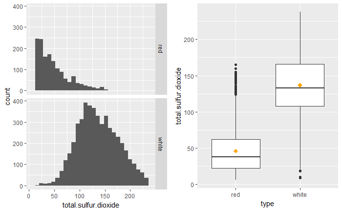

```r
p1_total.sulfur.dioxide <- ggplot(wine_data, aes(total.sulfur.dioxide)) +
  geom_histogram() +
  facet_grid(type~.)+
  scale_x_continuous(lim = c(min(wine_data$total.sulfur.dioxide), quantile(wine_data$total.sulfur.dioxide,  probs = c(99)/100)))
p2_total.sulfur.dioxide <- ggplot(wine_data, aes(type, total.sulfur.dioxide))+
  geom_boxplot()+
  stat_summary(fun.y=mean, color="orange", geom="point",
               shape=18, size=3)+
  scale_y_continuous(lim = c(min(wine_data$total.sulfur.dioxide), quantile(wine_data$total.sulfur.dioxide,  probs = c(99)/100)))
grid.arrange(p1_total.sulfur.dioxide, p2_total.sulfur.dioxide, nrow = 1)
```

We appreciate a right-skewed distribution for red wine and a slightly left-skewed distribution for white wine. In that case, we can see that total sulfure dioxide volumes are significantly higher for white wine.

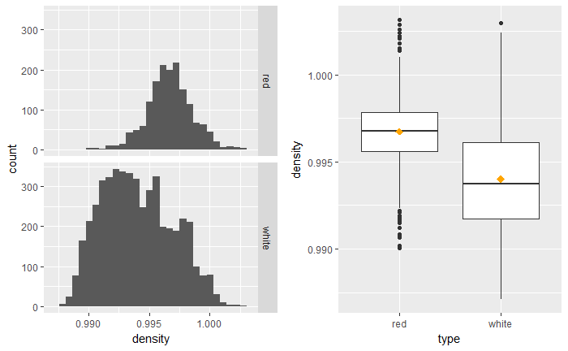

```r
p1_density <- ggplot(wine_data, aes(density)) +
  geom_histogram() +
  facet_grid(type~.)+
  scale_x_continuous(lim = c(min(wine_data$density), quantile(wine_data$density,  probs = c(99.9)/100)))
p2_density <- ggplot(wine_data, aes(type, density))+
  geom_boxplot()+
  stat_summary(fun.y=mean, color="orange", geom="point",
               shape=18, size=3)+
  scale_y_continuous(lim = c(min(wine_data$density), quantile(wine_data$density,  probs = c(99.9)/100)))
grid.arrange(p1_density, p2_density, nrow = 1)
```

Both wines seem to be normally distributed and red wines seem to have slightly higher density than white even though their boxplots overlap.

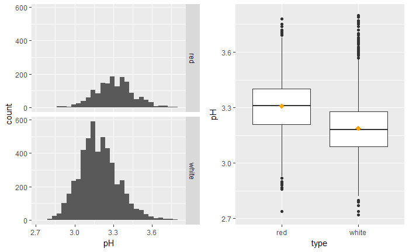

```r
p1_pH <- ggplot(wine_data, aes(pH)) +
  geom_histogram() +
  facet_grid(type~.)+
  scale_x_continuous(lim = c(min(wine_data$pH), quantile(wine_data$pH,  probs = c(99.9)/100)))
p2_pH <- ggplot(wine_data, aes(type, pH))+
  geom_boxplot()+
  stat_summary(fun.y=mean, color="orange", geom="point",
               shape=18, size=3)+
  scale_y_continuous(lim = c(min(wine_data$pH), quantile(wine_data$pH,  probs = c(99.9)/100)))
grid.arrange(p1_pH, p2_pH, nrow = 1)
```

pH is normally distributed for both wines and seems slightly higher for red wine.

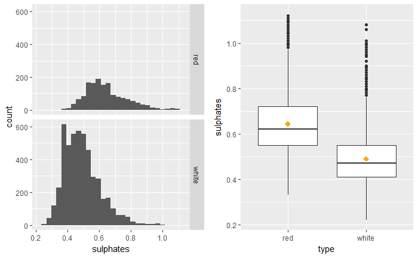

```r
p1_sulphates <- ggplot(wine_data, aes(sulphates)) +
  geom_histogram() +
  facet_grid(type~.)+
  scale_x_continuous(lim = c(min(wine_data$sulphates), quantile(wine_data$sulphates,  probs = c(99.5)/100)))
p2_sulphates <- ggplot(wine_data, aes(type, sulphates))+
  geom_boxplot()+
  stat_summary(fun.y=mean, color="orange", geom="point",
               shape=18, size=3)+
  scale_y_continuous(lim = c(min(wine_data$sulphates), quantile(wine_data$sulphates,  probs = c(99.5)/100)))
grid.arrange(p1_sulphates, p2_sulphates, nrow = 1)
```

Sulphates have a right-skewed distribution for both wines. Its concentration seems to be slightly higher for red wine.

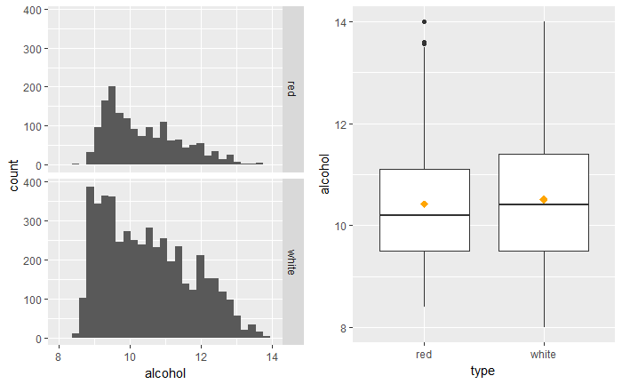

```r
p1_alcohol <- ggplot(wine_data, aes(alcohol)) +
  geom_histogram() +
  facet_grid(type~.)+
  scale_x_continuous(lim = c(min(wine_data$alcohol), quantile(wine_data$alcohol,  probs = c(99.9)/100)))
p2_alcohol <- ggplot(wine_data, aes(type, alcohol))+
  geom_boxplot()+
  stat_summary(fun.y=mean, color="orange", geom="point",
               shape=18, size=3)+
  scale_y_continuous(lim = c(min(wine_data$alcohol), quantile(wine_data$alcohol,  probs = c(99.9)/100)))
grid.arrange(p1_alcohol, p2_alcohol, nrow = 1)
```

Alcohol volume distribution is right-skewed for both wines. We can’t appreciate that both types of wine have significantly different alcohol degrees as they have very similar boxplots and mean.

# Univariate Analysis

### What is the structure of your dataset?

We have a sample size of 6497 wines (1599 red and 4898 white).

### What is/are the main feature(s) of interest in your dataset?

The main feature will be quality and we will try to determine the variables that make wine taste better.

### What other features in the dataset do you think will help support your into your feature(s) of interest?

Probably, alcohol, residual sugar, pH, acid and density will affect the quality.

### Did you create any new variables from existing variables in the dataset?

Yes, I added one column for the type of wine (red or white) and another one for the quality divided in three groups (excellent, average and deficient)

### Of the features you investigated, were there any unusual distributions? you perform any operations on the data to tidy, adjust, or change the form the data? If so, why did you do this?

There where outliers in most of the features. I trimmed some outliers little quantiles (<0.1) when plotting their distributions in order to appreciate them clearer.

# Bivariate Plots Section

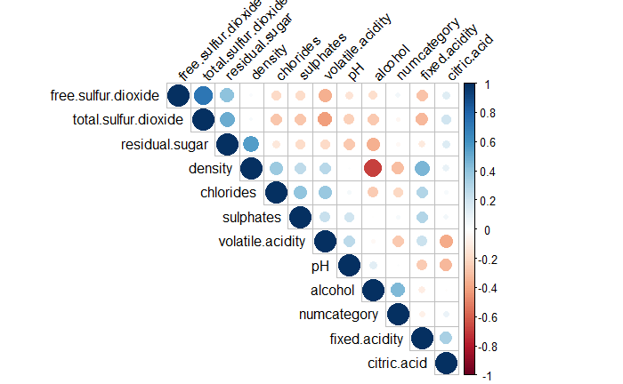

```r
wine_data$numcategory <- as.numeric(wine_data$quality)
mtx <- cor(wine_data[c(1:11, 16)])
wine_corrplot <- corrplot(mtx, type="upper", order="hclust", tl.col="black", tl.srt=45)
```

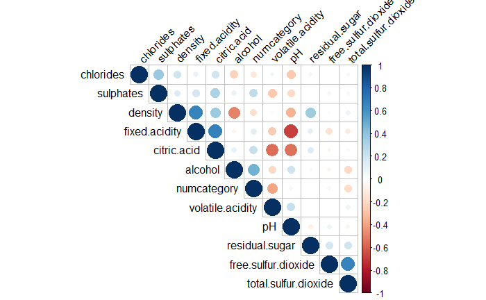

```r
mtx_red <- cor(subset(wine_data, wine_data['type'] == 'red')[c(1:11, 16)])
redwine_corrplot <- corrplot(mtx_red, type="upper", order="hclust", tl.col="black", tl.srt=45)
```

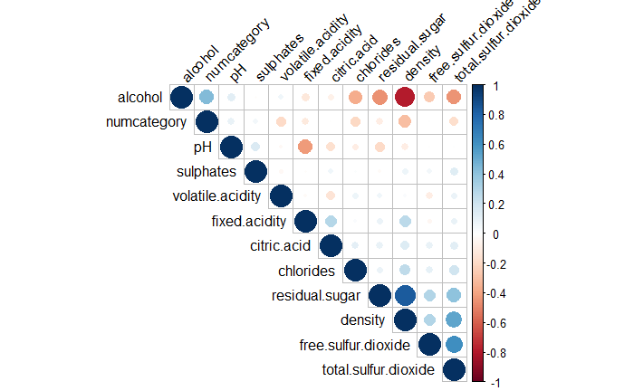

```r
mtx_white <- cor(subset(wine_data, wine_data['type'] == 'white')[c(1:11, 16)])
whitewine_corrplot <- corrplot(mtx_white, type="upper", order="hclust", tl.col="black", tl.srt=45)
```

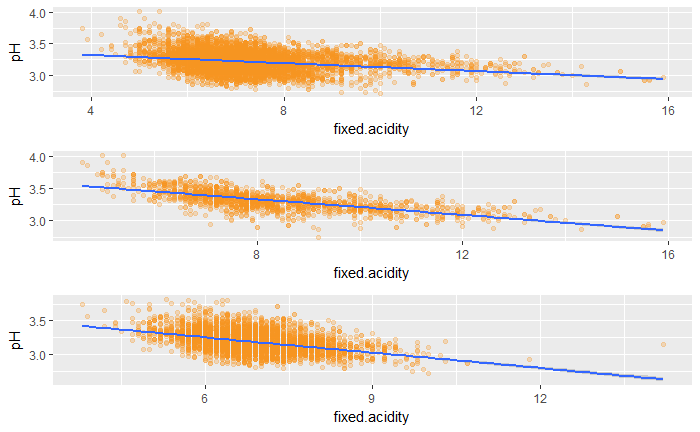

```r
# Fixed acidity vs pH
fixed.acidity_pH_wine <- ggplot(wine_data, aes(fixed.acidity, pH)) +
  geom_point(color = "#F79420", alpha = 1/4) +
  stat_smooth(method = 'lm')
fixed.acidity_pH_redwine <- ggplot(subset(wine_data, wine_data['type'] == 'red'), aes(fixed.acidity, pH)) +
  geom_point(color = "#F79420", alpha = 1/4) +
  stat_smooth(method = 'lm')
fixed.acidity_pH_whitewine <- ggplot(subset(wine_data, wine_data['type'] == 'white'), aes(fixed.acidity, pH)) +
  geom_point(color = "#F79420", alpha = 1/4) +
  stat_smooth(method = 'lm')
grid.arrange(fixed.acidity_pH_wine, fixed.acidity_pH_redwine,fixed.acidity_pH_whitewine, nrow = 3)
```

```r
cor(wine_data$fixed.acidity, wine_data$pH)
```

```
[1] -0.2527005
```

```r
cor(subset(wine_data, wine_data['type'] == 'red')$fixed.acidity, subset(wine_data, wine_data['type'] == 'red')$pH)
```

```
[1] -0.6829782
```

```r
cor(subset(wine_data, wine_data['type'] == 'white')$fixed.acidity, subset(wine_data, wine_data['type'] == 'white')$pH)
```

```
[1] -0.4258583
```

```r
# Citric acidity vs pH
citric.acid_pH_wine <- ggplot(wine_data, aes(citric.acid, pH)) +
  geom_point(color = "#F79420", alpha = 1/4) +
  stat_smooth(method = 'lm')
citric.acid_pH_redwine <- ggplot(subset(wine_data, wine_data['type'] == 'red'), aes(citric.acid, pH)) +
  geom_point(color = "#F79420", alpha = 1/4) +
  stat_smooth(method = 'lm')
citric.acid_pH_whitewine <- ggplot(subset(wine_data, wine_data['type'] == 'white'), aes(citric.acid, pH)) +
  geom_point(color = "#F79420", alpha = 1/4) +
  stat_smooth(method = 'lm')
grid.arrange(citric.acid_pH_wine, citric.acid_pH_redwine,citric.acid_pH_whitewine, nrow = 3)
```

[output not shown]

```r
cor(wine_data$citric.acid, wine_data$pH)
```

```
[1] -0.3298082
```

```r
cor(subset(wine_data, wine_data['type'] == 'red')$citric.acid, subset(wine_data, wine_data['type'] == 'red')$pH)
```

```
[1] -0.5419041
```

```r
cor(subset(wine_data, wine_data['type'] == 'white')$citric.acid, subset(wine_data, wine_data['type'] == 'white')$pH)
```

```
[1] -0.1637482
```

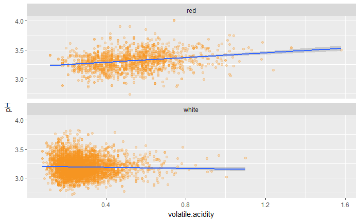

```r
# Volatile Acidity vs pH
ggplot(wine_data, aes(volatile.acidity, pH)) +
  facet_wrap(~type, ncol = 1) +
  geom_point(color = "#F79420", alpha = 1/4) +
  stat_smooth(method = 'lm')
```

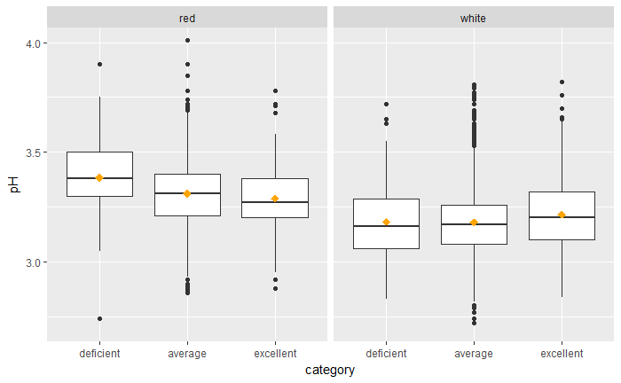

```r
wine_data$category<-factor(wine_data$category, levels=c("deficient", "average", "excellent"))
ggplot(wine_data, aes(category, pH)) +
  geom_boxplot()+
  facet_wrap(~type, ncol = 2) +
  coord_cartesian(ylim = c(2.7, 4)) +
  stat_summary(fun.y=mean, color="orange", geom="point",
               shape=18, size=3)
```

[figure not shown]

```r
  ggplot(wine_data, aes(category, quality)) +
  geom_boxplot()+
  facet_wrap(~type, ncol = 2) +
  coord_cartesian(ylim = c(8, 14)) +
  stat_summary(fun.y=mean, color="orange", geom="point",
               shape=18, size=3)
```

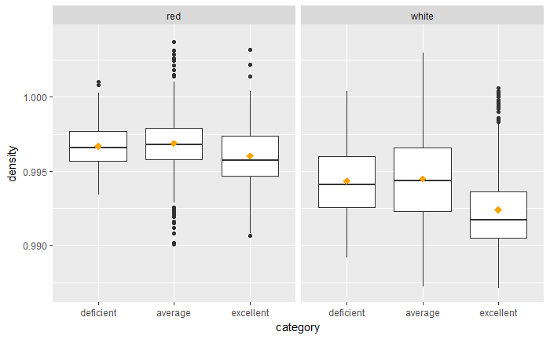

```r
ggplot(wine_data, aes(category, density)) +
  geom_boxplot()+
  facet_wrap(~type, ncol = 2) +
  coord_cartesian(ylim = c(0.987, 1.004)) +
  stat_summary(fun.y=mean, color="orange", geom="point",
               shape=18, size=3)
```

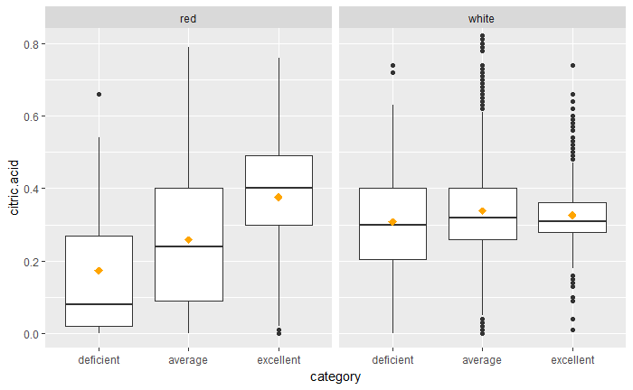

```r
ggplot(wine_data, aes(category, citric.acid)) +
  geom_boxplot()+
  facet_wrap(~type, ncol = 2) +
  coord_cartesian(ylim = c(0, 0.8)) +
  stat_summary(fun.y=mean, color="orange", geom="point",
               shape=18, size=3)
```

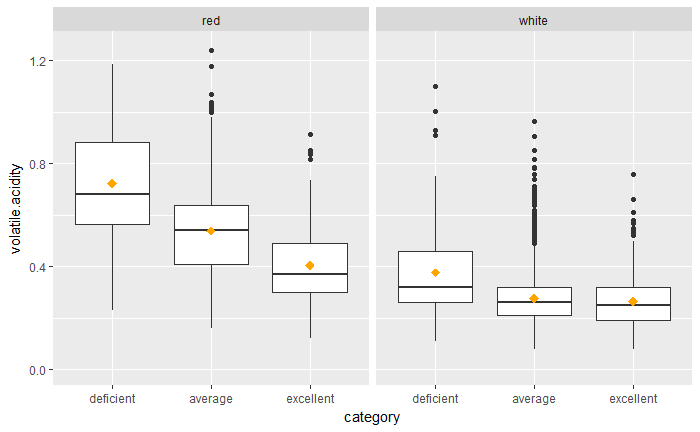

```r
ggplot(wine_data, aes(category, volatile.acidity)) +
  geom_boxplot()+
  facet_wrap(~type, ncol = 2) +
  coord_cartesian(ylim = c(0, 1.25)) +
  stat_summary(fun.y=mean, color="orange", geom="point",
               shape=18, size=3)
```

```r
NA
```

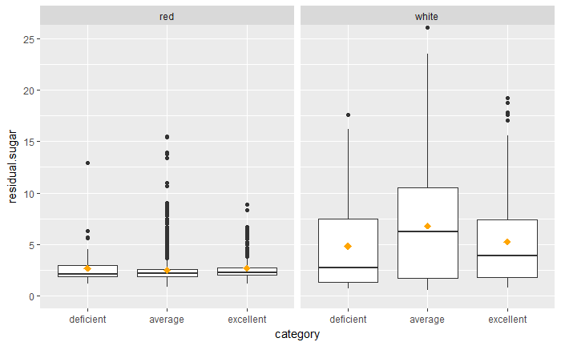

```r
ggplot(wine_data, aes(category, residual.sugar)) +
  geom_boxplot()+
  facet_wrap(~type, ncol = 2) +
  coord_cartesian(ylim = c(0, 25)) +
  stat_summary(fun.y=mean, color="orange", geom="point",
               shape=18, size=3)
```

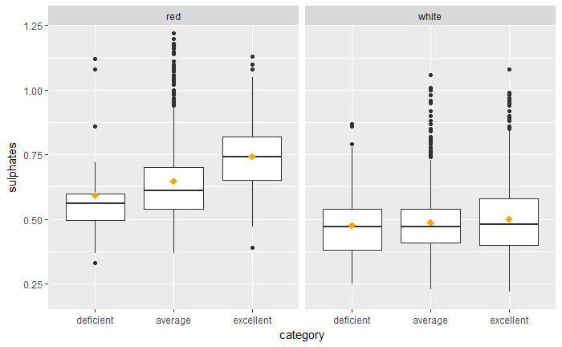

```r
ggplot(wine_data, aes(category, sulphates)) +
  geom_boxplot()+
  facet_wrap(~type, ncol = 2) +
  coord_cartesian(ylim = c(0.2, 1.2)) +
  stat_summary(fun.y=mean, color="orange", geom="point",
               shape=18, size=3)
```

I checked correlation between all the variables in wine dataset.